# Lecture #12

연속형 난수 발생과 모의실험

Junho Ahn

2022-09-08

## 일양분포

### 일양분포의 사용법

- 임의의 구간(min, max) 사이에서 동일한 확률분포
- 확률변수 $X$가 일양분포를 따르면 $X~U(min, max)$로 표현함

**일양분포에서 난수, 분위수 등을 계산하는 함수(~unif)의 매개변수**  
- x, q: 확률밀도함수값을 얻을 x벡터, 누적확률을 얻을 분위수 q벡터  
- p: 분위수를 얻을 확률값의 벡터  
- n: 발생할 난수의 개수  
- lower.tail: 논리값을 설정하며 TRUE이면 확률은 $P[X \leq x]$의 값으로 그렇지 않으면 $P[X \gt x]$을 계산

### 분폿값, 확률계산, 난수발생 함수 이름의 규칙

- 함수가 가진 규칙
  1. r ~ : 분포의 이름이 ~인 분포에서 난수를 발생하는 함수, r을 접두어로 사용
  2. d ~ : 분포의 이름이 ~인 분포에서 확률밀도함수값을 발생하는 함수, d를 접두어로 사용
  3. p ~ : 분포의 이름이 ~인 분포에서 누적확률함수 $F(x) = Pr[X \leq x]$를 계산, p를 접두어로 사용
  4. q ~ : 분포의 이름이 ~인 분포에서 분위수를 계산, q를 접두어로 사용

### 일양분포의 분폿값, 확률, 난수의 계산

**예시1** (난수발생과 분포의 모양)  
0과 1사이에서 일양분포에서 1000개의 난수를 발생하어 히스토그램으로 난수의 분포를 확인

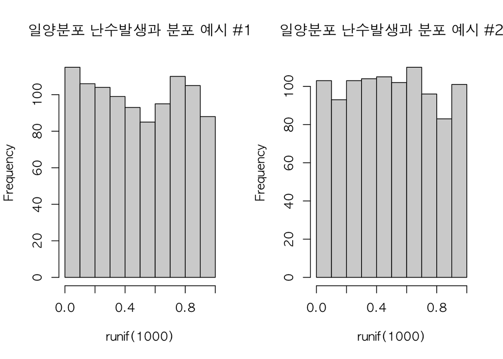

```r
par(mfrow=c(1,2), family = "AppleGothic")
hist(runif(1000), main = "일양분포 난수발생과 분포 예시 #1")
hist(runif(1000), main = "일양분포 난수발생과 분포 예시 #2")
```

매번 난수를 발생할 때마다 모양은 조금씩 달라지나 각 구간에 포함될 확률은 모두 같음

**예시2** (분위수, 분포함수, 확률밀도 함수)  
확률변수 $X$가 일양분포 $U(0,1)$에서 $X$가 0.25, 0.5 및 0.75일 때 확률밀도함수와 사분위수를 확인

`duinf()`함수를 사용하여 확률밀도함수 구하기

```r
p <- c(0.25, 0.5, 0.75)
dunif(p)
```

```
## [1] 1 1 1
```

일양분포 $U(0,1)$의 경우 모든 $X$에 대해 확률밀도 함수는 1임.

`qunif()`함수를 사용하여 사분위수 구하기

```r
qunif(p)
```

```
## [1] 0.25 0.50 0.75
```

(0,1)에서 균일한 분포이므로 0.25보다 작을 확률을 25%, 0.5보다 작을 확률은 50%, 0.75보다 작을 확률은 75%임.

`punif()`함수를 사용하여 사분위수 구하기

```r
punif(0.8) #0.8보다 같거나 작을 확률
```

```
## [1] 0.8
```

## 정규분포

기댓값(평균)을 기준으로 좌우대칭이며 전체 분포의 모양은 종모양인 분포

### 정규분포의 사용법

기댓값 $\mu$, 분산 $\sigma ^2$인 정규분포에서 사용하는 함수  
- 난수: rnorm  
- 확률밀도함수: dnorm  
- 누적분포함수: pnorm - 분위수: qnorm  
- 기댓값 $\mu$, 표준편차 $\sigma$는 생략될 수 있으며 생략된 경우 mean과 sd는 각각 0과 1인 표준정규분포를 사용

**정규분포에서 난수, 분위수 등을 계산하는 함수(~norm)의 매개변수**  
- x, q: 확률밀도함수값을 얻을 x벡터, 누적확률을 얻을 분위수 q벡터  
- p: 분위수를 얻을 확률값의 벡터  
- n: 발생할 난수의 개수  
- lower.tail: 논리값을 설정하며 TRUE이면 확률은 $P[X \leq x]$의 값으로 그렇지 않으면 $P[X \gt x]$을 계산

### 분포, 확률, 난수의 계산

**예시1** (분포함수 값의 계산)  
어떤 과목의 점수는 평균이 70점, 표준편차가 5점인 정규분포이다.  
이 과목의 점수가 80점이면 상위 몇 %에 해당하는지 확인

```r
1-pnorm(80, 70, 5) # 1- 80점 이하일 확률
```

```
## [1] 0.02275013
```

상위 약 2.3%에 해당되는 점수임.

**예시2** (자료) 통계학에서 $Z_\alpha$를 표준정규분포의 제100(1-$\alpha$)% 백분위수로 표시한다. 예를 들어 $Z_0.95$는 95% 백분위수이다.

표준정규분포에서 2.5% 백분위수 $Z_0.975$

```r
qnorm(0.025)
```

```
## [1] -1.959964
```

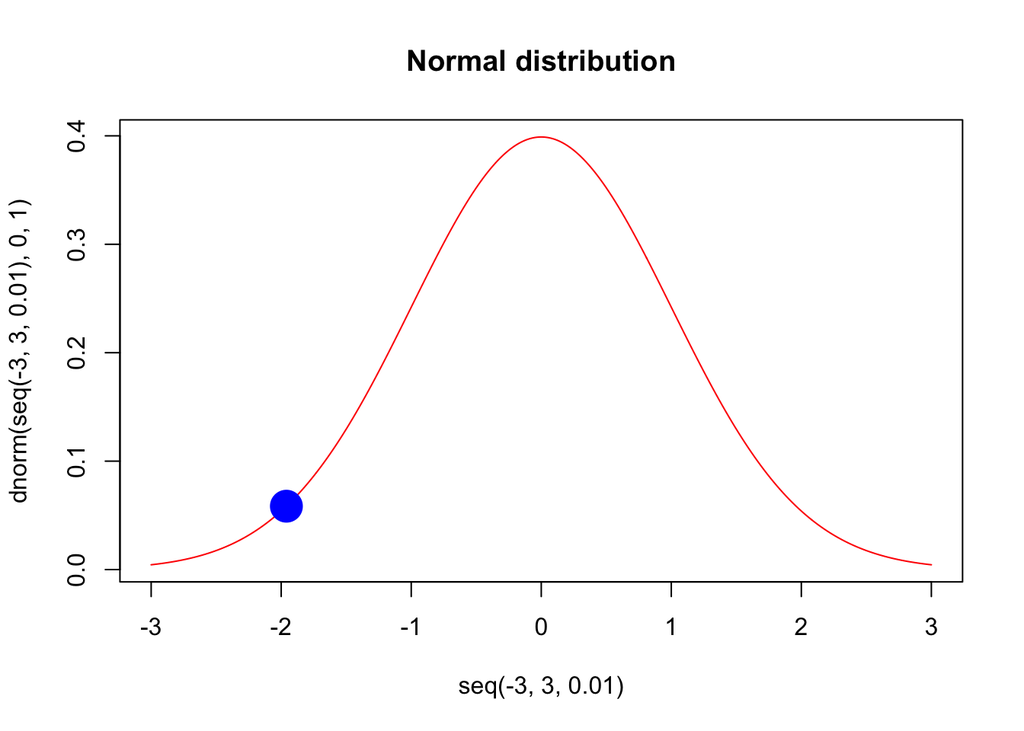

```r
plot(seq(-3,3, 0.01), dnorm(seq(-3,3,0.01), 0, 1), type = "l", col = "red", main = "Normal distribution")
points(qnorm(0.025), dnorm(qnorm(0.025)), col = "blue", cex = 3, pch = 16)
```

`dnorm()`함수를 사용하여 확률밀도함수 구하기

```r
dnorm(c(-1,0,1))
```

```
## [1] 0.2419707 0.3989423 0.2419707
```

표준정규분포의 확률밀도함수 $f(x) = \frac {1}{\sqrt 2 \pi} e^{\frac{-x^2}{2}}$의 값을 각각 -1, 0, 1에서 계산한 것임.

`pnorm()`함수를 사용하여 누적분포함수 구하기

```r
pnorm(c(-2.54, -1.96, 0, 1.96, 2.54))
```

```
## [1] 0.005542623 0.024997895 0.500000000 0.975002105 0.994457377
```

$Z$가 표준정규분포일 때 $Pr[Z \leq -2.54], Pr[Z \leq -1.96], Pr[Z \leq 0], Pr[Z \leq 1.96], Pr[Z \leq 2.54]$의 확률을 계산한 것임.

**예시3** (자료) 20대 한국남성의 키의 분포는 평균이 174, 표준편차가 2.5인 정규분포라고 가정하자. 키 기준으로 상위 5% 이내에 들어가려면 키가 최소 얼마라야 하는지 확인해 보자.

평균과 표준편차가 각각 174, 2.5인 분포에서 95% 백분위 찾기

```r
qnorm(0.95, 174, 2.5)
```

```
## [1] 178.1121
```

178.1121보다 크면 상위 5%임.

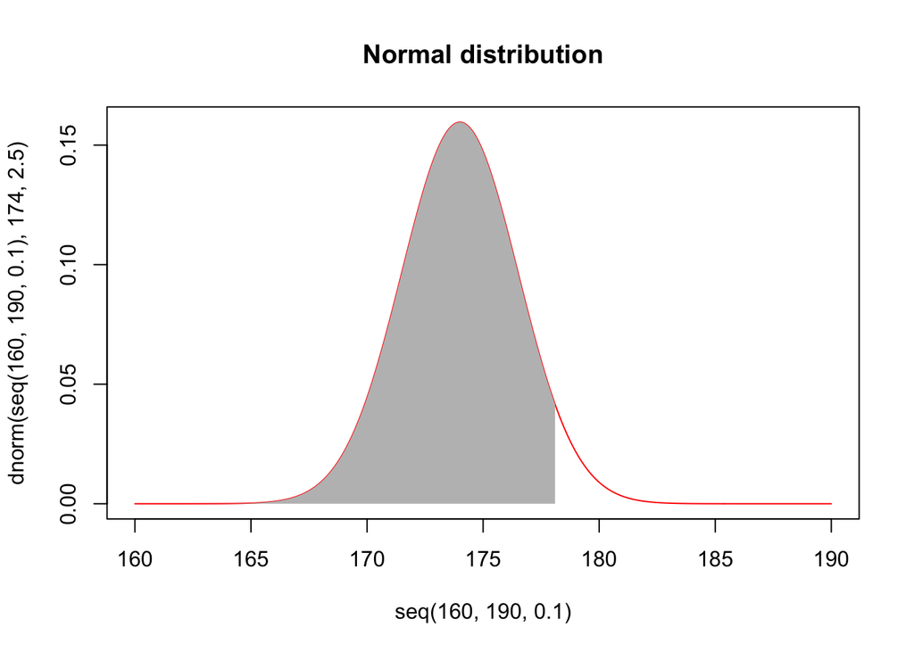

```r
plot(seq(160, 190, 0.1), dnorm(seq(160,190, 0.1), 174, 2.5), type = "l", col = "red", main = "Normal distribution")

##색칠할 범위 설정하기
areaX=seq(160, qnorm(0.95, 174, 2.5), 0.1)
areaY=dnorm(areaX, 174, 2.5)

##폴리곤 함수에 사용할 수 있도록 데이터 가공하기
xp=c(areaX,rev(areaX))
yp=c(rep(0,length(areaY)),rev(areaY))

##폴리곤 함수 그리기
polygon(xp,yp,col="gray",border=NA)
```

**예제4** (난수로 분포 확인하기) 평균이 10, 분산이 5인 정규분포에서 1000개의 난수를 발생하여 이 1000개의 평균과 분산이 각각 10과 5에 가까운지 확인해 보고 1000개의 분포가 종모양, 좌우대칭인지 히스토그램으로 확인해보자.

```r
x <- rnorm(1000, 10, sqrt(5))
mean(x)
```

```
## [1] 10.04355
```

```r
var(x)
```

```
## [1] 4.660958
```

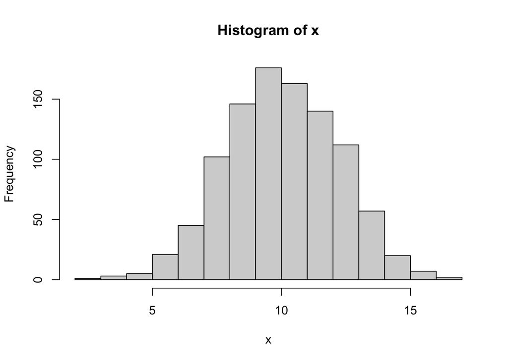

```r
hist(x)
```

## 정규분포 난수 만들기

$u_1$과 $u_2$가 독립이며 일양분포 $U(0,1)$을 따를 경우

$$z_1=\sqrt{-2log(u_1)} \; cos(2 \pi
u_2)$$
$$z_2=\sqrt{-2log(u_1)} \;
sin(2 \pi u_2)$$

위와 같이 $z_1$과 $z_2$를 얻으면 $z_1$과 $z_2$의 분포는 독립인 표준정규분포를 따름  
이를 Box-Muller 변환이라고 함

### Box-Muller 변환

#### 예시1

(난수의 응용) Box-Muller변환을 사용하여 n개의 표준정규분포를 따르는 난수를 생성하는 함수를 작성하여 난수를 발생하여 얻은 결과를 사용하여 히스토그램을 그려서 분포가 표준정규분포에 가까운지 확인

```r
boxmuller <- function(size){

  if(size%%2==0){
    nn <- size/2
  } else {
    nn <- (size+1)/2
  } #end else-if

  u1 <- runif(nn)
  u2 <- runif(nn)

  z1 <- sqrt(-2*log(u1))*cos(2*pi*u2)
  z2 <- sqrt(-2*log(u1))*sin(2*pi*u2)

  z <- c(z1, z2)

  if(size%%2 != 0){
    z <- z[-1]
  } #end if

  list(z=z)
} #end function
```

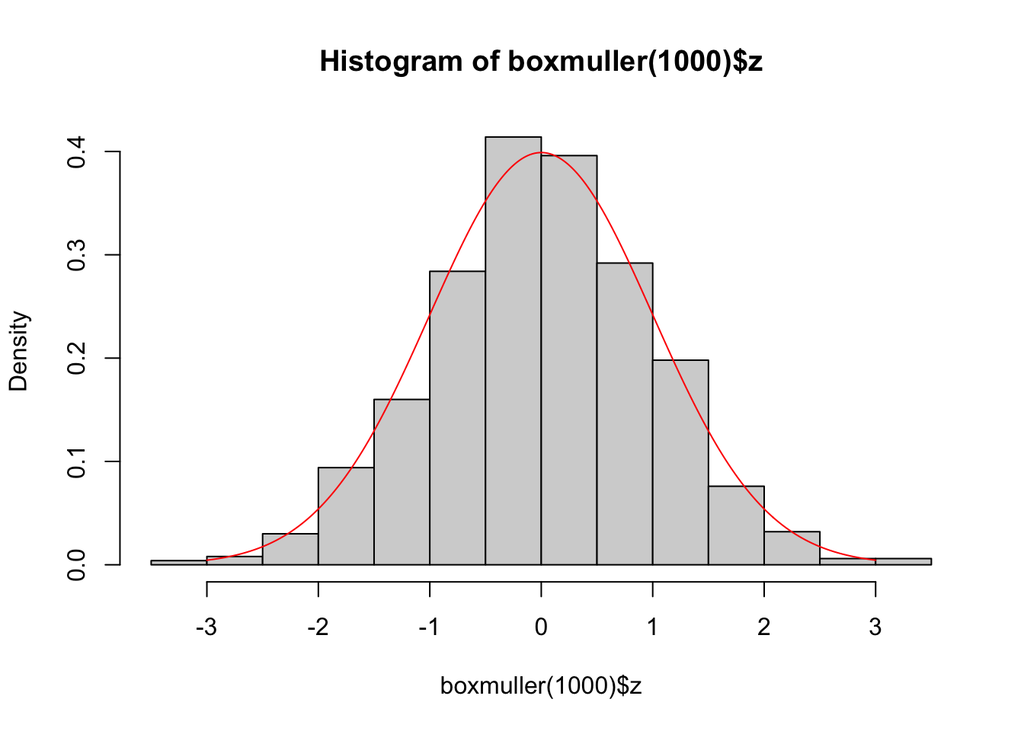

```r
hist(boxmuller(1000)$z, prob=T)
lines(x <- seq(-3,3,by=0.02),dnorm(x),col="red")
```

#### 예시2

(Box-Muller 변환과 rnorm의 비교) Box-Muller 변환으로 얻은 10,000개의 난수에서 얻은 10%, 20%, … , 90% 백분위수와 표준정규분포의 이론적 백분위수를 비교

```r
x <- boxmuller(10000)$z
p <- seq(0.1, 0.9, by=0.1)
quantile(x, probs = p)
```

```
##         10%         20%         30%         40%         50%         60%
## -1.28666939 -0.84625435 -0.53370346 -0.27973234 -0.01479574  0.23811637
##         70%         80%         90%
##  0.52318906  0.83719032  1.27386604
```

```r
qnorm(p)
```

```
## [1] -1.2815516 -0.8416212 -0.5244005 -0.2533471  0.0000000  0.2533471  0.5244005
## [8]  0.8416212  1.2815516
```

Box-Muller 변환으로 얻은 10,000개의 난수에서 얻은 백분위수와 표준정규분포의 이론적 백분위수가 매우 유사함을 알 수 있다.

좀 더 확실하게 비교하기 위해 quantile()와 qnorm()의 결과 차이를 계산해 본다.

```r
quantile(x, probs = p) - qnorm(p) #차이 계산
```

```
##          10%          20%          30%          40%          50%          60%
## -0.005117824 -0.004633116 -0.009302948 -0.026385237 -0.014795737 -0.015230737
##          70%          80%          90%
## -0.001211454 -0.004430917 -0.007685527
```

차이가 0에 가까움